# Term Project

##### 處理離群值

```r
sapply(X[,6:9], quantile, prob=c(.999, .9995, .9999)) # Check Quantile
```

```
##        items   pieces     total    gross
## 99.9%     54  81.0000  9009.579 1824.737
## 99.95%    62  94.2895 10611.579 2179.817
## 99.99%    82 133.0000 16044.401 3226.548
```

```r
X = subset(X, items<=62 & pieces<95 & total<16000) # Remove Outliers
nrow(X) #119328
```

```
## [1] 119328
```

##### 每周交易次數

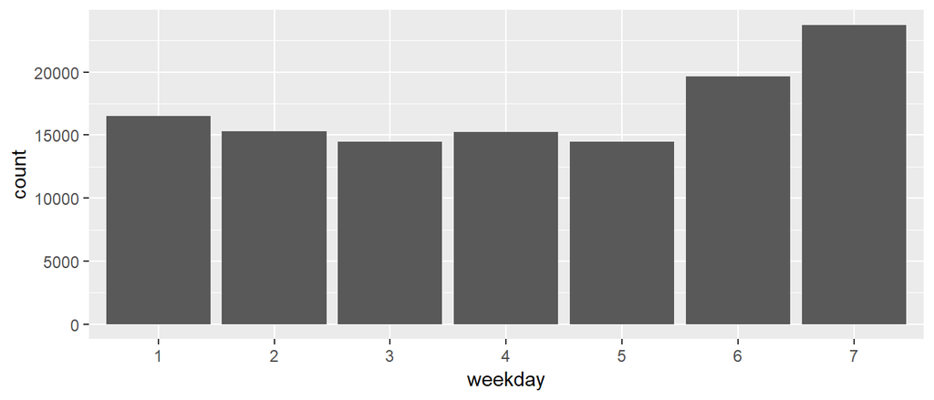

```r
month = format(X$date,"%m")
X$month= format(X$date,"%m")
weekday = format(X$date,"%u")
ggplot(X,aes(x=weekday))+geom_bar()
```

##### 每月與每週的交易次數(依月份個別作圖)

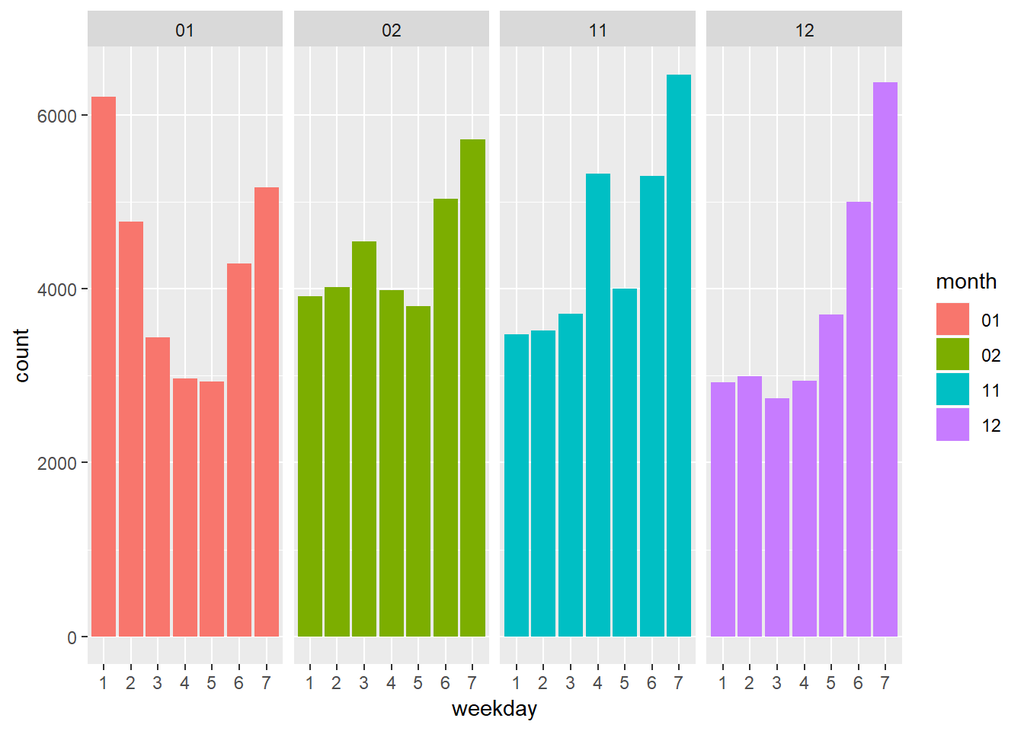

```r
ggplot()+geom_bar(data=X,aes(x=weekday,fill=month))+facet_grid(~month)
```

##### 每周交易次數與年齡層之間的關係(標準化)

```r
library(d3heatmap)
table(X$age,format(X$date,"%u")) %>%
  {./rowSums(.)} %>%
  as.data.frame.matrix %>%
  d3heatmap(F,F,col=colorRamp(c("#00bfff","#ffffe6","#ff6666")))
```

[interactive chart not shown]

#### 1.3 顧客資料：`A`

##### 顧客資料彙整

```r
d0 = max(X$date) + 1
A = X %>% mutate(
  days = as.integer(difftime(d0, date, units="days"))
  ) %>%
  group_by(cust) %>% summarise(
    r = min(days),      # 最近一次購買距今天數
    s = max(days),      # 最早一次購買距今天數
    f = n(),            # 購買次數
    m = mean(total),    # 平均購買金額
    rev = sum(total),   # 總營收貢獻
    raw = sum(gross),   # 總毛利貢獻
    age = age[1],       # 年齡層
    area = area[1]      # 郵遞區號
  ) %>% data.frame      # 32241
```

##### 顧客摘要

```r
summary(A)
```

```
##      cust                 r                s                f
##  Length:32241       Min.   :  1.00   Min.   :  1.00   Min.   : 1.000
##  Class :character   1st Qu.:  9.00   1st Qu.: 56.00   1st Qu.: 1.000
##  Mode  :character   Median : 26.00   Median : 92.00   Median : 2.000
##                     Mean   : 37.45   Mean   : 80.78   Mean   : 3.701
##                     3rd Qu.: 60.00   3rd Qu.:110.00   3rd Qu.: 4.000
##                     Max.   :120.00   Max.   :120.00   Max.   :85.000
##        m                rev              raw              age
##  Min.   :    8.0   Min.   :     8   Min.   : -784.0   Length:32241
##  1st Qu.:  365.0   1st Qu.:   707   1st Qu.:   75.0   Class :character
##  Median :  705.7   Median :  1750   Median :  241.0   Mode  :character
##  Mean   :  993.1   Mean   :  3152   Mean   :  484.6
##  3rd Qu.: 1291.0   3rd Qu.:  3968   3rd Qu.:  612.0
##  Max.   :12636.0   Max.   :127686   Max.   :20273.0
##      area
##  Length:32241
##  Class :character
##  Mode  :character
##
##
##
```

##### 變數的分布情況

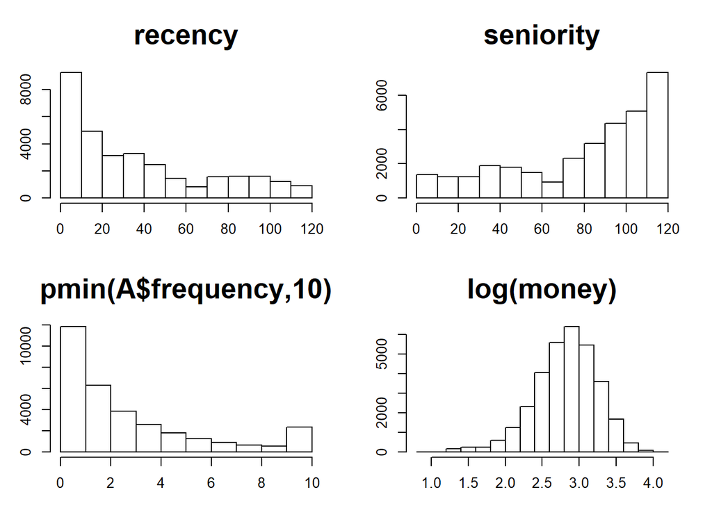

```r
par(mfrow=c(2,2), mar=c(3,3,4,2))
hist(A$r,freq=T,main="recency",xlab="",ylab="",cex.main=2)
hist(A$s,freq=T,main="seniority",xlab="",ylab="",cex.main=2)
hist(pmin(A$f,10),0:10,freq=T,main="pmin(A$frequency,10)",xlab="",ylab="",cex.main=2)
hist(log(A$m,10),freq=T,main="log(money)",xlab="",ylab="",cex.main=2)
```

圖形與變數解析：

- recency：最近一次購買距今天數
  - 圖形中可以發現，最近一次購買距今天數10天內的人數較多，代表有些較活躍的顧客，最近持續購買中。
  - 理論而言，最近一次購買距今天數越短代表是比較好的顧客，提供即時的商品或服務最可能會有反應。
- seniority：最早一次購買距今天數
  - 高起來的地方，代表在當時吸收很多顧客
- frequency：在限定時間內的購買次數
  - 購買次數越多的顧客，代表他的滿意度越高，忠誠度也可能越高。
  - 以pmin來看`購買次數`，設置上限為10次，超過10次以10次計算的加總，發現呈現離散分布。
- log(money)：money代表購買金額，或客單價
  - 取log之後，會變的較為常態分佈，較能看出趨勢變化。

在商務數據分析中，上述的RFM為數據分析中最好的指標，我們可以透過RFM模型了解顧客的價值以及對企業的幫助。

```r
A0 = A; X0 = X; Z0 = Z
```

### 2. 分群

##### RFM顧客分群

```r
set.seed(111)
A$grp = kmeans(scale(A[,c(2,4,5)]),7)$cluster
table(A$grp)
```

```
##
##     1     2     3     4     5     6     7
##  7709  1812  5210  1374 10513  4753   870
```

利用集群式分析k-means，將資料依照不同屬性將顧客做分群。  
k-means分完群會把分群的向量放在“cluster”這個欄位裡面，用table(A$grp)看族群大小。

##### 顧客群組屬性

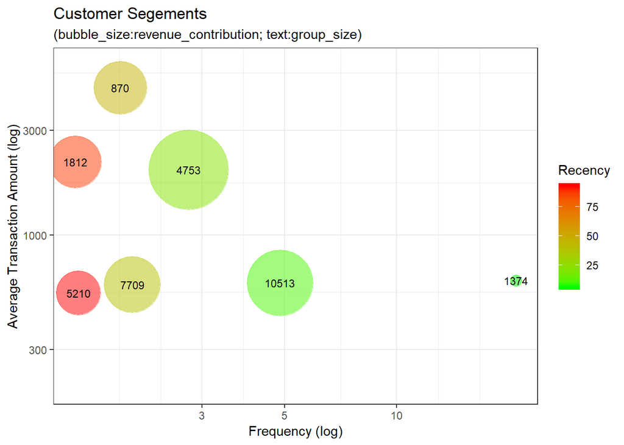

```r
group_by(A, grp) %>% summarise(
  recent=mean(r),
  freq=mean(f),
  money=mean(m),
  size=n() ) %>%
  mutate( revenue = size*money/1000 )  %>%
  filter(size > 1) %>%
  ggplot(aes(x=freq, y=money)) +
  geom_point(aes(size=revenue, col=recent),alpha=0.5) +
  scale_size(range=c(4,30)) +
  scale_color_gradient(low="green",high="red") +
  scale_x_log10() + scale_y_log10(limits=c(200,6000)) +
  geom_text(aes(label = size ),size=3) +
  theme_bw() + guides(size=F) +
  labs(title="Customer Segements",
       subtitle="(bubble_size:revenue_contribution; text:group_size)",
       color="Recency") +
  xlab("Frequency (log)") + ylab("Average Transaction Amount (log)")
```

#### 2.2 規則分群

##### 平均購買週期

```r
K = as.integer(sum(A$s[A$f>1]) / sum(A$f[A$f>1])) ; K
```

```
## [1] 17
```

回購顧客的平均購買週期 `K = 17 days`

##### 顧客分群規則

```r
STS = c("N1","N2","C1","C2","D1","D2","D3")
Status = function(rx,fx,mx,sx,K) {factor(
  ifelse(sx < 3.5*K,
         ifelse(fx*mx > 1593, "N2", "N1"),
         ifelse(rx < 2*K,
                ifelse(sx/fx < 0.41*K,"C2","C1"),
                ifelse(rx < 4*K,"D1",
                       ifelse(rx < 5*K,"D2","D3")))), STS)}
```

依照三個參數(seniority, frequency, recency)把顧客分群，用ifelse條件式來將顧客區分新潛力顧客、新顧客、核心顧客、主力顧客、瞌睡顧客、半睡顧客、沉睡顧客。

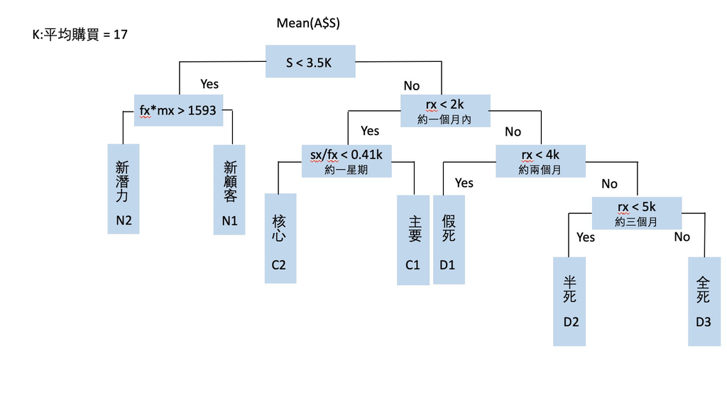

圖三、顧客分群規則

##### 顧客資料彙整

```r
d0 = max(X$date) + 1
A = X %>% mutate(
  days = as.integer(difftime(d0, date, units="days"))
  ) %>%
  group_by(cust) %>% summarise(
    r = min(days),            # 最近一次購買距今天數
    s = max(days),            # 第一次購買距今天數
    f = n(),                  # 購買次數
    m = mean(total),          # 平均購買金額
    rev = sum(total),         # 總營收貢獻
    raw = sum(gross),         # 總毛利貢獻
    age = age[1],             # 年齡層
    area = area[1],           # 郵遞區號
    Status= Status(r,f,m,s,K) # 顧客分群
  ) %>% data.frame            # 28599
summary(A)
```

```
##      cust                 r                s                f
##  Length:32241       Min.   :  1.00   Min.   :  1.00   Min.   : 1.000
##  Class :character   1st Qu.:  9.00   1st Qu.: 56.00   1st Qu.: 1.000
##  Mode  :character   Median : 26.00   Median : 92.00   Median : 2.000
##                     Mean   : 37.45   Mean   : 80.78   Mean   : 3.701
##                     3rd Qu.: 60.00   3rd Qu.:110.00   3rd Qu.: 4.000
##                     Max.   :120.00   Max.   :120.00   Max.   :85.000
##
##        m                rev              raw              age
##  Min.   :    8.0   Min.   :     8   Min.   : -784.0   Length:32241
##  1st Qu.:  365.0   1st Qu.:   707   1st Qu.:   75.0   Class :character
##  Median :  705.7   Median :  1750   Median :  241.0   Mode  :character
##  Mean   :  993.1   Mean   :  3152   Mean   :  484.6
##  3rd Qu.: 1291.0   3rd Qu.:  3968   3rd Qu.:  612.0
##  Max.   :12636.0   Max.   :127686   Max.   :20273.0
##
##      area           Status
##  Length:32241       N1: 5846
##  Class :character   N2: 2831
##  Mode  :character   C1:11568
##                     C2:  794
##                     D1: 4278
##                     D2: 2343
##                     D3: 4581
```

##### 顧客資料視覺化

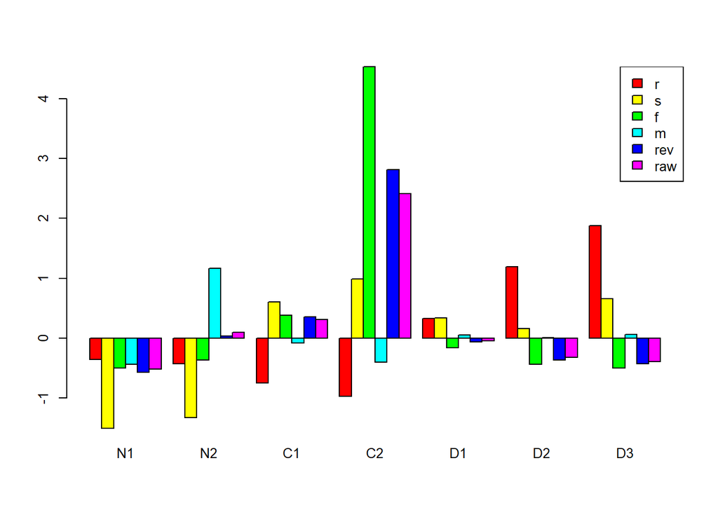

```r
Sta = A$Status
A_IND= A[,2:7] %>% scale() %>% data.frame
par(cex=0.8)
split(A_IND,Sta) %>% sapply(colMeans) %>% barplot(beside=T,col=rainbow(6))
legend('topright',legend=colnames(A_IND),fill=rainbow(6))
```

**D族群：S值偏高，代表是早期就出現的顧客，r值偏高，距離上次購買日數已有一段時間，採用比較刺激的行銷策略喚醒此群顧客，但行銷主力並不在此。**

D1：假死顧客，瞌睡顧客對於這家店的認識有一定時間，有一半的機會成為主力顧客，但也有另一半的機會成為半睡顧客，且極少數會仍保留於此狀態中，雖然CLV偏低，但若成流轉成為主力顧客仍有一定潛力存在，為了增加成為主力顧客的機會，我們利用e-mail行銷，針對此群顧客寄出老顧客的限時特惠商品或是折價券，吸引瞌睡顧客重新回到店裡消費，再加以利用會員制度讓顧客留住在店中。

D2：半死顧客，此群顧客的CLV值低，且多數會流轉成為沈睡顧客，少數會變成瞌睡顧客，由於顧客保留價值低，故對於此群顧客我們採用不分群的行銷策略模式，利用特惠、週年慶、特賣的方式吸引顧客上門。

D3：全死顧客，此類顧客極難再轉為其他種類顧客，此群顧客價值低，保留所造成的效果也不明顯，故採用與S2一樣的不針對性做法，採用較消極的行銷方式。

**C族群：採用提高忠誠度的行銷方式保留此群顧客，其為我們的行銷主力對象。**

C2：核心顧客：核心顧客的CLV為最高，其也不太容易轉成其他群顧客，在會員至當中此群顧客最終會成為最高等級會員，以最高等級的會員優惠、無微不至的特別服務，讓核心顧客有美好的消費體驗，持續保留核心顧客。

**N族群：S值偏低，代表是近期出現的顧客，r值偏低，距離上次購買日數短，採用持續吸引的方式將新顧客到店消費成為習慣，成為新的R族群顧客，為行銷主力對象。**

N1：新顧客：新顧客屬於還在觀察、觀望的一族群，其消費貢獻不高，CLV極低，流轉為潛力顧客的機會也不高，但必須持續培養新顧客成為忠誠顧客，增加店的業績成長，故即使效益看似不高也必須做一些保留的行銷策略，可以利用一些充滿新鮮感的行銷方式像是集點好禮、現金回饋、新客好禮禮包分階段贈送的方式吸引其持續到店消費。

### 3. 資料切割

#### 3.1 準備預測變數 (X)

##### 劃分日期

Remove data after the demarcation date(`2001-02-01`)

```r
feb01 = as.Date("2001-02-01")
Z = subset(Z0, date < feb01)    # 618212
```

```r
X = group_by(Z, tid) %>% summarise(
  date = first(date),  # 交易日期
  cust = first(cust),  # 顧客 ID
  age = first(age),    # 顧客 年齡級別
  area = first(area),  # 顧客 居住區別
  items = n(),                # 交易項目(總)數
  pieces = sum(qty),          # 產品(總)件數
  total = sum(price),         # 交易(總)金額
  gross = sum(price - cost)   # 毛利
  ) %>% data.frame     # 88387
summary(X)
```

```
##       tid             date                cust
##  Min.   :    1   Min.   :2000-11-01   Length:88387
##  1st Qu.:22098   1st Qu.:2000-11-23   Class :character
##  Median :44194   Median :2000-12-12   Mode  :character
##  Mean   :44194   Mean   :2000-12-15
##  3rd Qu.:66291   3rd Qu.:2001-01-12
##  Max.   :88387   Max.   :2001-01-31
##      age                area               items             pieces
##  Length:88387       Length:88387       Min.   :  1.000   Min.   :  1.000
##  Class :character   Class :character   1st Qu.:  2.000   1st Qu.:  3.000
##  Mode  :character   Mode  :character   Median :  5.000   Median :  6.000
##                                        Mean   :  6.994   Mean   :  9.453
##                                        3rd Qu.:  9.000   3rd Qu.: 12.000
##                                        Max.   :112.000   Max.   :339.000
##      total             gross
##  Min.   :    5.0   Min.   :-1645.0
##  1st Qu.:  230.0   1st Qu.:   23.0
##  Median :  522.0   Median :   72.0
##  Mean   :  888.7   Mean   :  138.3
##  3rd Qu.: 1120.0   3rd Qu.:  174.0
##  Max.   :30171.0   Max.   : 8069.0
```

##### 處理離群值

```r
sapply(X[,6:9], quantile, prob=c(.999, .9995, .9999)) # Check Quantile
```

```
##          items   pieces     total    gross
## 99.9%  56.0000  84.0000  9378.684 1883.228
## 99.95% 64.0000  98.0000 11261.751 2317.087
## 99.99% 85.6456 137.6456 17699.325 3389.646
```

```r
X = subset(X, items<=64 & pieces<=98 & total<=11260) # Remove Outliers
```

##### 顧客資料彙整(去除離群值後)

```r
d0 = max(X$date) + 1
A = X %>% mutate(
  days = as.integer(difftime(d0, date, units="days"))
  ) %>%
  group_by(cust) %>% summarise(
    r = min(days),            # 最近一次購買距今天數
    s = max(days),            # 第一次購買距今天數
    f = n(),                  # 購買次數
    m = mean(total),          # 平均購買金額
    rev = sum(total),         # 總營收貢獻
    raw = sum(gross),         # 總毛利貢獻
    age = age[1],             # 年齡層
    area = area[1],           # 郵遞區號
    Status= Status(r,f,m,s,K) # 顧客分群
  ) %>% data.frame            # 28584
summary(A)
```

```
##      cust                 r               s               f
##  Length:28584       Min.   : 1.00   Min.   : 1.00   Min.   : 1.000
##  Class :character   1st Qu.:11.00   1st Qu.:47.00   1st Qu.: 1.000
##  Mode  :character   Median :21.00   Median :68.00   Median : 2.000
##                     Mean   :32.12   Mean   :61.27   Mean   : 3.089
##                     3rd Qu.:53.00   3rd Qu.:83.00   3rd Qu.: 4.000
##                     Max.   :92.00   Max.   :92.00   Max.   :60.000
##
##        m                rev             raw              age
##  Min.   :    8.0   Min.   :    8   Min.   : -742.0   Length:28584
##  1st Qu.:  359.4   1st Qu.:  638   1st Qu.:   70.0   Class :character
##  Median :  709.5   Median : 1566   Median :  218.0   Mode  :character
##  Mean   : 1012.4   Mean   : 2711   Mean   :  420.8
##  3rd Qu.: 1315.0   3rd Qu.: 3426   3rd Qu.:  535.0
##  Max.   :10634.0   Max.   :99597   Max.   :15565.0
##
##      area           Status
##  Length:28584       N1:7199
##  Class :character   N2:3471
##  Mode  :character   C1:9017
##                     C2: 814
##                     D1:4196
##                     D2:3005
##                     D3: 882
```

#### 3.2 準備目標變數 (Y)

```r
feb = filter(X0, date>= feb01) %>% group_by(cust) %>%
  summarise(amount = sum(total))  # 16899
```

##### The Target for Regression - `A$amount`

```r
A = merge(A, feb, by="cust", all.x=T)
```

##### The Target for Classification - `A$buy`

```r
A$buy = !is.na(A$amount)
```

##### 交易資料摘要

```r
summary(A)
```

```
##      cust                 r               s               f
##  Length:28584       Min.   : 1.00   Min.   : 1.00   Min.   : 1.000
##  Class :character   1st Qu.:11.00   1st Qu.:47.00   1st Qu.: 1.000
##  Mode  :character   Median :21.00   Median :68.00   Median : 2.000
##                     Mean   :32.12   Mean   :61.27   Mean   : 3.089
##                     3rd Qu.:53.00   3rd Qu.:83.00   3rd Qu.: 4.000
##                     Max.   :92.00   Max.   :92.00   Max.   :60.000
##
##        m                rev             raw              age
##  Min.   :    8.0   Min.   :    8   Min.   : -742.0   Length:28584
##  1st Qu.:  359.4   1st Qu.:  638   1st Qu.:   70.0   Class :character
##  Median :  709.5   Median : 1566   Median :  218.0   Mode  :character
##  Mean   : 1012.4   Mean   : 2711   Mean   :  420.8
##  3rd Qu.: 1315.0   3rd Qu.: 3426   3rd Qu.:  535.0
##  Max.   :10634.0   Max.   :99597   Max.   :15565.0
##
##      area           Status        amount         buy
##  Length:28584       N1:7199   Min.   :    8   Mode :logical
##  Class :character   N2:3471   1st Qu.:  454   FALSE:15342
##  Mode  :character   C1:9017   Median :  993   TRUE :13242
##                     C2: 814   Mean   : 1499
##                     D1:4196   3rd Qu.: 1955
##                     D2:3005   Max.   :28089
##                     D3: 882   NA's   :15342
```

##### Contest Dataset

```r
X = subset(X, cust %in% A$cust & date < as.Date("2001-02-01"))
Z = subset(Z, cust %in% A$cust & date < as.Date("2001-02-01"))
set.seed(2019)
spl = sample.split(A$buy, SplitRatio=0.46)
c(nrow(A), sum(spl), sum(!spl))
```

```
## [1] 28584 13148 15436
```

```r
A2 = subset(A, buy) %>% mutate_at(c("m","rev","amount"), log10)
n = nrow(A2)
set.seed(2019)
spl2 = 1:n %in% sample(1:n, round(0.7*n))
c(nrow(A2), sum(spl2), sum(!spl2))
```

```
## [1] 13242  9269  3973
```

### 4. 建立模型

#### 類別模型

接著我們來預測顧客是否會回購，使用類別迴歸模型來預測保留率。

##### 訓練與測試資料分割

```r
TR = subset(A, spl)
TS = subset(A, !spl)
```

##### 建立類別模型

```r
#利用邏輯式回歸來預測顧客是否會回購
glm1 = glm(buy ~ ., TR[,c(2,4,10,12)], family=binomial)
summary(glm1)
```

```
##
## Call:
## glm(formula = buy ~ ., family = binomial, data = TR[, c(2, 4,
##     10, 12)])
##
## Deviance Residuals:
##     Min       1Q   Median       3Q      Max
## -3.2598  -0.8709  -0.7483   1.0628   1.7319
##
## Coefficients:
##              Estimate Std. Error z value Pr(>|z|)
## (Intercept) -1.092741   0.064173 -17.028  < 2e-16 ***
## r           -0.006918   0.001642  -4.212 2.53e-05 ***
## f            0.380386   0.015933  23.874  < 2e-16 ***
## StatusN2    -0.011414   0.066520  -0.172  0.86376
## StatusC1     0.303399   0.065445   4.636 3.55e-06 ***
## StatusC2    -0.667286   0.431741  -1.546  0.12221
## StatusD1     0.259101   0.080874   3.204  0.00136 **
## StatusD2     0.143080   0.108346   1.321  0.18664
## StatusD3     0.101581   0.159704   0.636  0.52474
## ---
## Signif. codes:  0 '***' 0.001 '**' 0.01 '*' 0.05 '.' 0.1 ' ' 1
##
## (Dispersion parameter for binomial family taken to be 1)
##
##     Null deviance: 18156  on 13147  degrees of freedom
## Residual deviance: 15379  on 13139  degrees of freedom
## AIC: 15397
##
## Number of Fisher Scoring iterations: 6
```

##### 估計類別模型準確性

```r
pred =  predict(glm1, TS, type="response")
cm = table(actual = TS$buy, predict = pred > 0.5) ; cm
```

```
##        predict
## actual  FALSE TRUE
##   FALSE  6988 1297
##   TRUE   3336 3815
```

```r
acc.ts = cm %>% {sum(diag(.))/sum(.)}; acc.ts          # 正確率 0.69998
```

```
## [1] 0.6998575
```

```r
colAUC(pred, TS$buy)                                   # 辨識率 0.749
```

```
##                     [,1]
## FALSE vs. TRUE 0.7490067
```

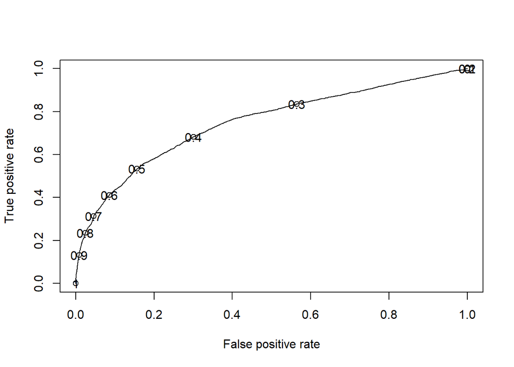

```r
prediction(pred, TS$buy) %>%                           # ROC CURVE
  performance("tpr", "fpr") %>%
  plot(print.cutoffs.at=seq(0,1,0.1))
```

- 混淆矩陣可以看出我們預測的結果及實際結果的關係。
- 辨識率(AUC)作為檢視一個模型鑑別能力的好壞，也是ROC曲線下的面積。

#### 數量模型

```r
A2 = subset(A, A$buy) %>% mutate_at(c("m","rev","amount"), log10)
TR2 = subset(A2, spl2)
TS2 = subset(A2, !spl2)
```

##### 建立數量模型

```r
lm1 = lm(amount ~ ., TR2[,c(2,4,5:7,8,10,11)])
summary(lm1)
```

```
##
## Call:
## lm(formula = amount ~ ., data = TR2[, c(2, 4, 5:7, 8, 10, 11)])
##
## Residuals:
##      Min       1Q   Median       3Q      Max
## -1.99816 -0.23253  0.05305  0.28879  1.30641
##
## Coefficients:
##               Estimate Std. Error t value Pr(>|t|)
## (Intercept)  1.316e+00  4.601e-02  28.610  < 2e-16 ***
## r           -2.139e-04  4.385e-04  -0.488 0.625641
## f            1.669e-02  2.516e-03   6.634 3.45e-11 ***
## m            4.346e-01  3.414e-02  12.729  < 2e-16 ***
## rev          6.842e-02  3.342e-02   2.047 0.040668 *
## raw          6.571e-05  8.604e-06   7.637 2.44e-14 ***
## agea25       3.559e-02  2.526e-02   1.409 0.158948
## agea30       8.869e-02  2.315e-02   3.831 0.000128 ***
## agea35       1.154e-01  2.284e-02   5.050 4.49e-07 ***
## agea40       9.924e-02  2.346e-02   4.229 2.37e-05 ***
## agea45       8.097e-02  2.433e-02   3.328 0.000879 ***
## agea50       5.709e-02  2.692e-02   2.120 0.033996 *
## agea55       2.914e-02  3.123e-02   0.933 0.350788
## agea60       3.038e-02  3.263e-02   0.931 0.351860
## agea65      -3.080e-02  2.831e-02  -1.088 0.276654
## agena        7.512e-02  3.913e-02   1.920 0.054904 .
## StatusN2    -5.071e-02  2.013e-02  -2.519 0.011775 *
## StatusC1    -1.261e-02  1.822e-02  -0.692 0.488924
## StatusC2     4.081e-02  3.595e-02   1.135 0.256334
## StatusD1    -1.260e-03  2.282e-02  -0.055 0.955950
## StatusD2     5.852e-02  3.012e-02   1.943 0.052063 .
## StatusD3     6.350e-02  4.689e-02   1.354 0.175728
## ---
## Signif. codes:  0 '***' 0.001 '**' 0.01 '*' 0.05 '.' 0.1 ' ' 1
##
## Residual standard error: 0.4266 on 9247 degrees of freedom
## Multiple R-squared:  0.286,  Adjusted R-squared:  0.2844
## F-statistic: 176.4 on 21 and 9247 DF,  p-value: < 2.2e-16
```

從上面可看出僅有某些變數對模型具有顯著的解釋力，而獲得判定係數為0.2861的表現。

##### 估計數量模型準確性

```r
r2.tr = summary(lm1)$r.sq
SST = sum((TS2$amount - mean(TR2$amount))^ 2)
SSE = sum((predict(lm1, TS2) -  TS2$amount)^2)
r2.ts = 1 - (SSE/SST)
c(r2.tr, r2.ts)
```

```
## [1] 0.2860110 0.2894077
```

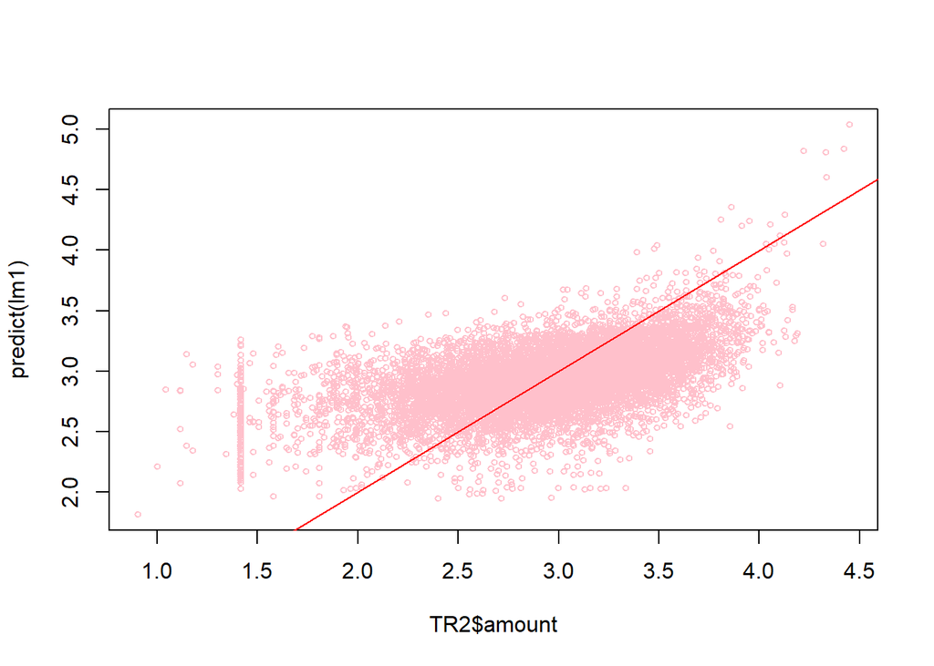

```r
plot(TR2$amount, predict(lm1), col='pink', cex=0.65)
abline(0,1,col='red')
```

### 5. 估計顧客終身價值(CLV)

```r
d0 = max(X0$date) + 1
B = X0 %>%
  filter(date >= as.Date("2000-12-01")) %>%
  mutate(days = as.integer(difftime(d0, date, units="days"))) %>%
  group_by(cust) %>% summarise(
    r = min(days),            # 最近一次購買距今天數
    s = max(days),            # 第一次購買距今天數
    f = n(),                  # 購買次數
    m = mean(total),          # 平均購買金額
    rev = sum(total),         # 總營收貢獻
    raw = sum(gross),         # 總毛利貢獻
    age = age[1],             # 年齡層
    area = area[1],           # 郵遞區號
    Status= Status(r,f,m,s,K) # 顧客分群
  ) %>% data.frame            # 28531
```

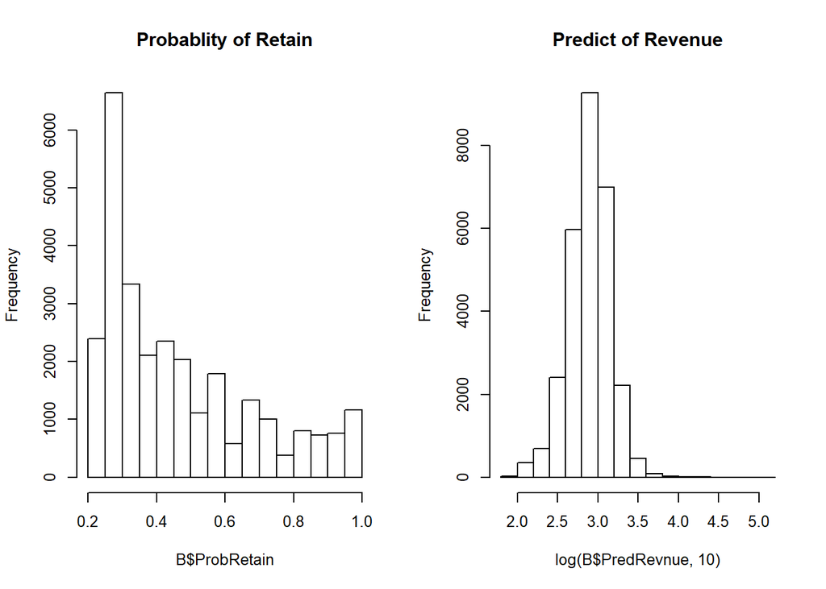

```r
B$ProbRetain = predict(glm1, B, type="response")    # 預測2002.03的保留率
B2 = B %>% mutate_at(c("m","rev"), log10)
B$PredRevnue = 10^predict(lm1, B2)                  # 預測2002.03的購買金額
par(mfrow=c(1,2), cex=0.8)
hist(B$ProbRetain,main="Probablity of Retain")
hist(log(B$PredRevnue,10),main="Predict of Revenue")
```

##### 估計顧客終身價值(CLV)

透過計算顧客終生價值讓我們了解每一個顧客的潛在價值有多大 。

顧客$i$的終生價值

$$V_i = \sum_{t=0}^N g \times m_i \frac{r_i^t}{(1+d)^t} = g \times m_i \sum_{t=0}^N (\frac{r_i}{1+d})^t$$

$m_i$、$r_i$：顧客$i$的預期(每期)營收貢獻、保留機率

$g$、$d$：公司的(稅前)營業利潤利率、資金成本

```r
g = 0.5   # (稅前)獲利率
N = 5     # 期數 = 5
d = 0.1   # 利率 = 10%

B$CLV = g * B$PredRevnue * rowSums(sapply(
  0:N, function(i) (B$ProbRetain/(1+d))^i ) )

summary(B$CLV)
```

```
##      Min.   1st Qu.    Median      Mean   3rd Qu.      Max.
##     50.87    429.35    668.45   1030.70   1090.34 249413.98
```

##### 比較各族群的價值

將各族群的保留率、回購金額、顧客終身價值彙整成表格，了解各族群的消費狀態及性質，並擬定相對應的行銷策略。

```r
#各族群的保留率、回購金額、顧客終身價值
sapply(B[,11:13], tapply, B$Status, mean)
```

```
##    ProbRetain PredRevnue       CLV
## N1  0.3243238   590.6821  420.5757
## N2  0.4043458  1188.5908  964.9624
## C1  0.6843856  1025.6383 1410.8890
## C2  0.9773858  2955.1972 6890.3757
## D1  0.4228782   862.6215  735.2745
## D2  0.2626713   862.7844  569.4093
## D3  0.2309751   877.2373  555.3783
```

##### C1族群的預測保留率和購買金額

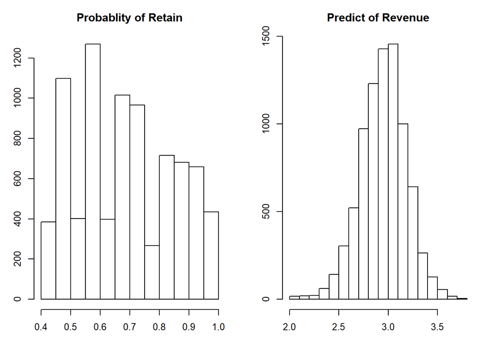

```r
par(mfrow=c(1,2), mar=c(4,3,3,2), cex=0.8)
hist(B$ProbRetain[B$Status=="C1"],main="Probablity of Retain",xlab="")
hist(log(B$PredRevnue[B$Status=="C1"],10),main="Predict of Revenue",xlab="")
```

##### C1族群 各年齡的消費分布&各地區的消費分布

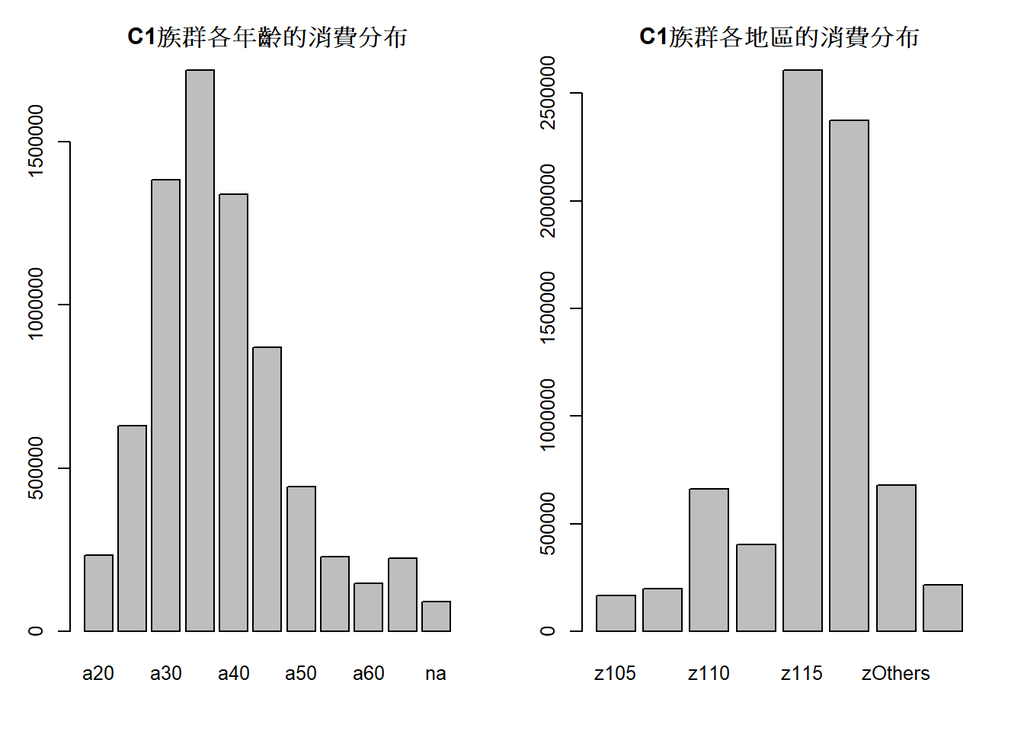

```r
Target=filter(B,Status=="C1")
par(mfrow=c(1,2), mar=c(4,3,3,2), cex=0.8)
barplot(tapply(Target$m,Target$age,sum),main="C1族群各年齡的消費分布")
barplot(tapply(Target$m,Target$are,sum),main="C1族群各地區的消費分布")
```

#### 模擬成本與效果的關係

##### 帶有參數的函數

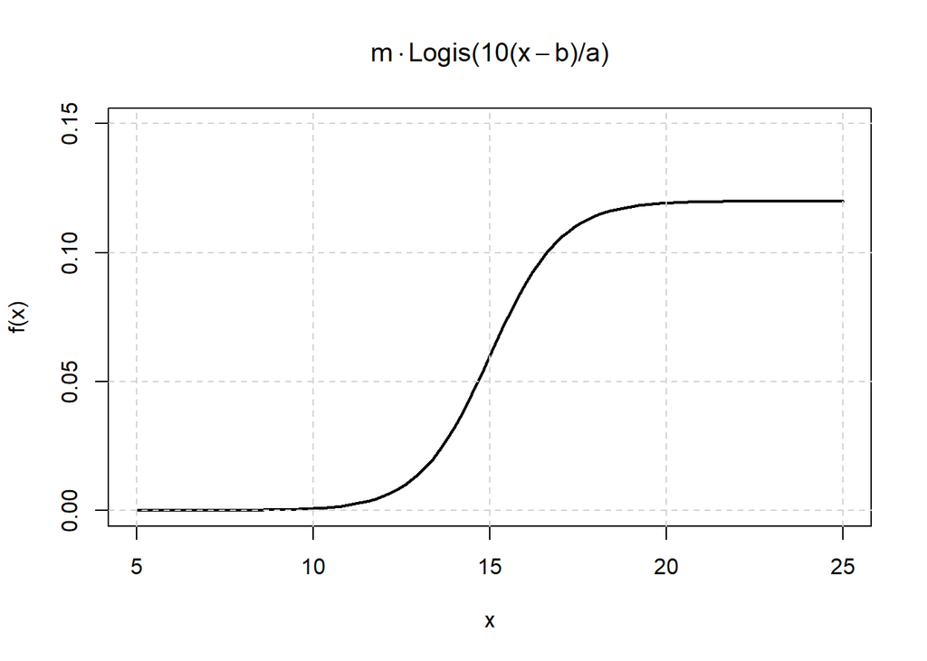

```r
m=0.12; a=10; b=15
curve(m*plogis((10/a)*(x-b)), 5, 25, lwd=2, ylim=c(0, 0.15),
      main=TeX('$m \\cdot Logis(10(x - b)/a)$'), ylab="f(x)")
abline(h=seq(0,0.2,0.05),v=seq(0,30,5),col='lightgrey',lty=2)
```

$$k_0=f(x)=m \cdot Logis[10(x - b)/a]$$

##### 使用`manipulate`套件做模擬

`manipulate()`不能在Rmd直接執行，需要另外開一個R窗格，把以下程式碼Copy過去跑

```r
manipulate({
  curve(m*plogis((10/a)*(x-b)), 0, 30, lwd=2, ylim=c(0, 0.25),
        main = TeX('$m \\cdot Logis(10(x - b)/a)$'), ylab="f(x)")
  abline(h=seq(0,0.2,0.05),v=seq(0,30,5),col='lightgrey',lty=2)
},
m = slider(0.05, 0.25,  0.20, step=0.01),
a = slider(  10,   30,    20, step=1),
b = slider(   4,   20,    15, step=1)
)
```

##### 使用模擬方法找到最佳策略(參數)，情境一

##### 回購率上升速度快，但須投入較多資金

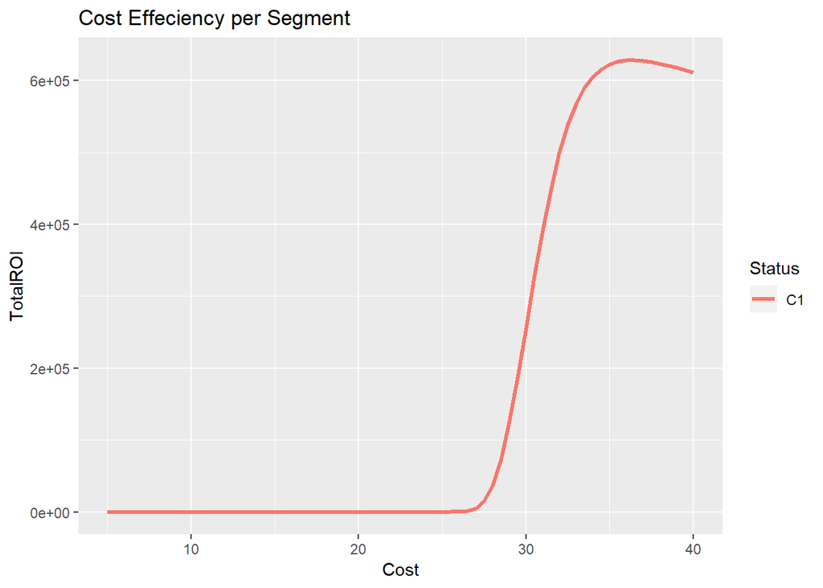

```r
m=0.12; a=15; b=30
do.call(rbind, lapply(seq(5,40,0.5), function(c){
  p = m*plogis((10/a)*(c-b))
  Target %>% mutate(
    PI = ifelse(ProbRetain<=(1-p), p, 1-ProbRetain) * PredRevnue - c
  ) %>%
    group_by(Status) %>% summarise(
      Cost = c,
      Group.Sz = n(),
      No.Target = sum(PI>0),
      AvgROI = mean(PI[PI>0]),
      TotalROI = sum(PI[PI>0])
    ) } ) ) %>%
  ggplot(aes(x=Cost, y=TotalROI, col=Status)) +
  geom_line(size=1.2) +
  ggtitle("Cost Effeciency per Segment ")
```

# 情境二

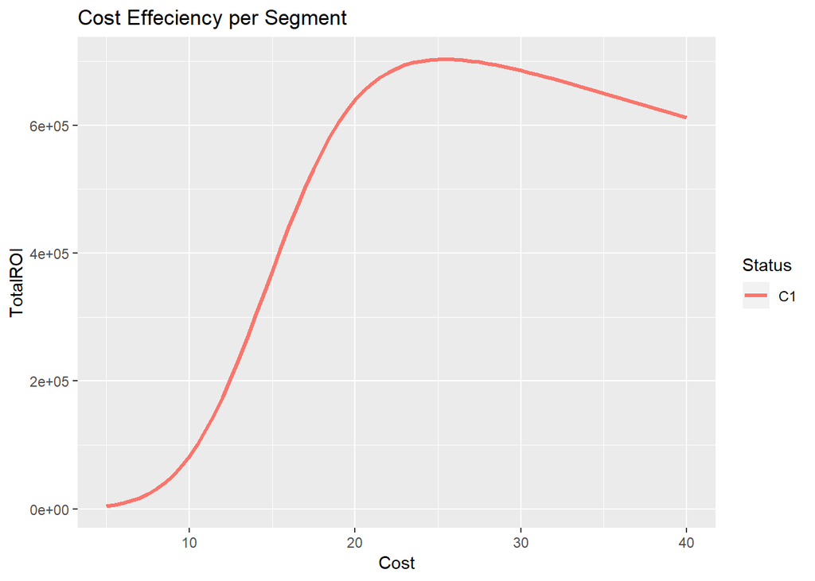

```r
m=0.12; a=30; b=15
do.call(rbind, lapply(seq(5,40,0.5), function(c){
  p = m*plogis((10/a)*(c-b))
  Target %>% mutate(
    PI = ifelse(ProbRetain<=(1-p), p, 1-ProbRetain) * PredRevnue - c
  ) %>%
    group_by(Status) %>% summarise(
      Cost = c,
      Group.Sz = n(),
      No.Target = sum(PI>0),
      AvgROI = mean(PI[PI>0]),
      TotalROI = sum(PI[PI>0])
    ) } ) ) %>%
  ggplot(aes(x=Cost, y=TotalROI, col=Status)) +
  geom_line(size=1.2) +
  ggtitle("Cost Effeciency per Segment ")
```

```r
manipulate({
  do.call(rbind, lapply(seq(5,40,0.5), function(c){
    p = m*plogis((10/a)*(c-b))
    B %>% mutate(
      PI = ifelse(ProbRetain<=(1-p), p, 1-ProbRetain) * PredRevnue - c
    ) %>%
      group_by(Status) %>% summarise(
        Cost = c,
        Group.Sz = n(),
        No.Target = sum(PI>0),
        AvgROI = mean(PI[PI>0]),
        TotalROI = sum(PI[PI>0])
      ) } ) ) %>%
    ggplot(aes(x=Cost, y=TotalROI, col=Status)) +
    geom_line(size=1.2) +
    ggtitle("Cost Effeciency per Segment ")
},
m = slider(0.05, 0.25,  0.20, step=0.01),
a = slider(  10,   30,    15, step=1),
b = slider(   4,   20,    15, step=1)
)
```

**情境一回購機率提升較快，但成本需要花比較多** **情境二回購機率提升較慢，但成本相對較少** **兩者收益差不多主要還是差在回購機率的提升速度** **我們傾向細水長流型** **除了成本較低** **以及曇花一現的狀況外** **最主要我們可以更加瞭解客群** **往後若想要加強CRM的部分** **我們能有更多的資料方便我們著手**